# 603-Walmart Sales

##### 2.2 Testing our assumptions

**Plots**

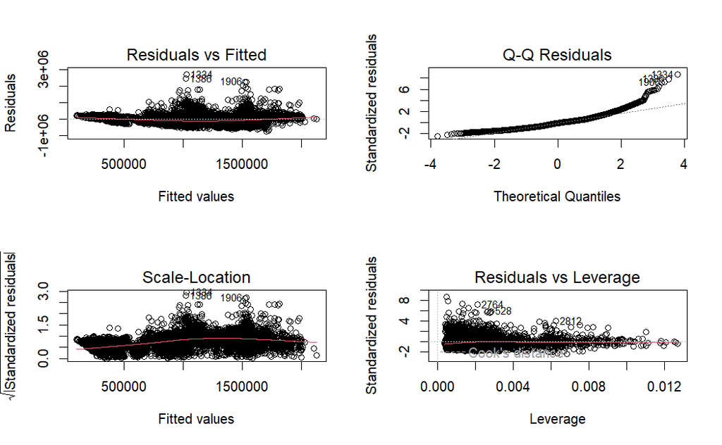

```r
par(mfrow=c(2,2))
plot(interact02)
```

**Equal Variances**

**The Breusch-Pagan Test** The hypothesis: $H_{0}:\text{common variance}; H_{\alpha}:\text{non-common variance}$

```r
library(lmtest)
bptest(interact02)
```

```
    studentized Breusch-Pagan test

data:  interact02
BP = 277.96, df = 13, p-value < 2.2e-16
```

- p value <0.05, reject Null Hypo so we conclude we do have heteroscedasticity.

**Normality Assumption**

**Shapiro Test**

```r
shapiro.test(residuals(interact02))
```

```
Error in shapiro.test(residuals(interact02)) :
  sample size must be between 3 and 5000
```

- We can’t use Shapiro test for Normality because sample size > 5000

**Anderson-Darling test** - Since Shapiro-Wilk Test couldnt perform on large sample size over 5000 rows. We use Anderson-Darling test instead - The Hypothesis : $H_{0}: \text{we have normality}; \; H_{\alpha}: \text{we do not have normality}$

```r
library(nortest)
interact02_results <- ad.test(residuals(interact02))
print(interact02_results)
```

```
    Anderson-Darling normality test

data:  residuals(interact02)
A = 66.312, p-value < 2.2e-16
```

- pvalue <0.05, reject Null, we don’t have normality.

**Multicollinearity**

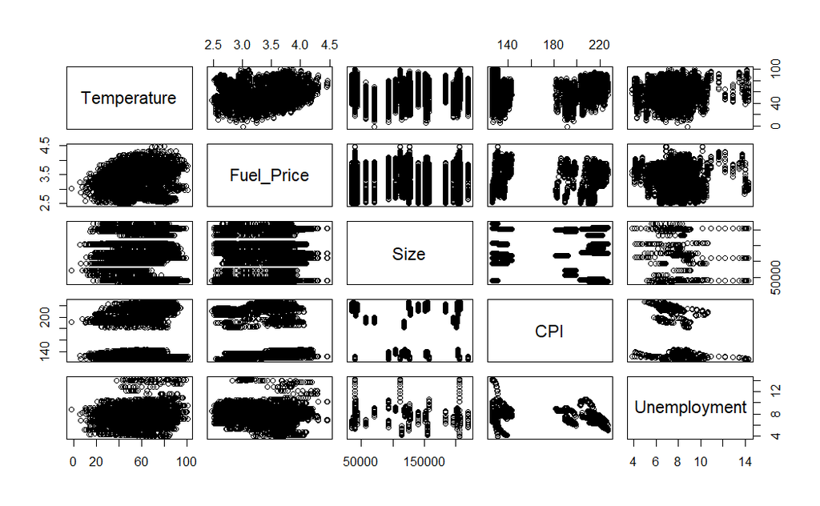

```r
library(mctest) #for VIF
full=lm(Weekly_Sales~Temperature+Fuel_Price+CPI+Unemployment+Size+Holiday_Flag,data=walmartNEW)
pairs(~Temperature+Fuel_Price+Size+CPI+Unemployment+Size, data=walmartNEW)
```

```r
library(car)
imcdiag(full, method="VIF")
```

```
Call:
imcdiag(mod = full, method = "VIF")


 VIF Multicollinearity Diagnostics

                   VIF detection
Temperature     1.1373         0
Fuel_Price      1.0845         0
CPI             1.2218         0
Unemployment    1.1577         0
Size            1.0160         0
Holiday_FlagYes 1.0294         0

NOTE:  VIF Method Failed to detect multicollinearity


0 --> COLLINEARITY is not detected by the test

===================================
```

```r
vif(full)
```

```
 Temperature   Fuel_Price          CPI Unemployment         Size Holiday_Flag
    1.137262     1.084491     1.221815     1.157670     1.015990     1.029364
```

- From the output, we can see that 1<VIF<5, which suggests that there is no correlation between these predictors.

**Conclusion on interaction model**

- Normality : There is a concern on normality in this model
- Linearity: The residuals are scattered around the horizontal line without a clear pattern, which is a good indication of linearity.
- Equal Variance: From The Breusch-Pagan Test result with extremely low p value, we we do have heteroscedasticity
- Multicollinearity: There is no correlation between selected predictors

##### 2.3 Improve this model transformation if homodescacity and normality does not meet.

**Box-Cox Transformation**

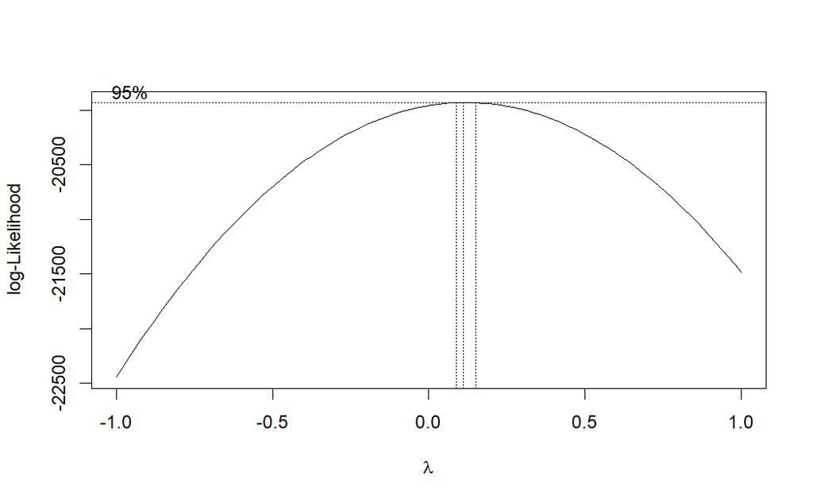

```r
library(MASS)
bc=boxcox(interact02,lambda=seq(-1,1))
```

```r
bestlambda=bc$x[which(bc$y==max(bc$y))]
bestlambda
```

```
[1] 0.1111111
```

**Fit model with this lambda**

```r
bcmodel=lm((((Weekly_Sales^0.1111)-1)/0.1111) ~
             Temperature+Fuel_Price+CPI+Unemployment+Size+Holiday_Flag+
             Temperature*Fuel_Price+ Temperature*CPI +
             Fuel_Price*CPI+
             CPI*Unemployment+CPI*Size+
             Unemployment*Size + Size*Holiday_Flag,data=walmartNEW)
summary(bcmodel)
```

```
Call:
lm(formula = (((Weekly_Sales^0.1111) - 1)/0.1111) ~ Temperature +
    Fuel_Price + CPI + Unemployment + Size + Holiday_Flag + Temperature *
    Fuel_Price + Temperature * CPI + Fuel_Price * CPI + CPI *
    Unemployment + CPI * Size + Unemployment * Size + Size *
    Holiday_Flag, data = walmartNEW)

Residuals:
    Min      1Q  Median      3Q     Max
-3.0366 -0.9235 -0.1073  0.8012  7.1105

Coefficients:
                         Estimate Std. Error t value Pr(>|t|)
(Intercept)             3.639e+01  8.691e-01  41.872  < 2e-16 ***
Temperature             9.432e-03  8.962e-03   1.052  0.29263
Fuel_Price             -1.012e+00  2.003e-01  -5.051 4.53e-07 ***
CPI                    -6.460e-02  4.551e-03 -14.196  < 2e-16 ***
Unemployment           -8.303e-01  5.004e-02 -16.593  < 2e-16 ***
Size                    5.128e-05  1.939e-06  26.443  < 2e-16 ***
Holiday_FlagYes         1.801e-01  1.426e-01   1.263  0.20666
Temperature:Fuel_Price  2.331e-03  2.182e-03   1.068  0.28559
Temperature:CPI        -7.582e-05  2.422e-05  -3.131  0.00175 **
Fuel_Price:CPI          5.533e-03  9.718e-04   5.694 1.30e-08 ***
CPI:Unemployment        6.517e-03  3.053e-04  21.345  < 2e-16 ***
CPI:Size               -2.903e-08  6.740e-09  -4.307 1.68e-05 ***
Unemployment:Size      -1.175e-06  1.435e-07  -8.188 3.16e-16 ***
Size:Holiday_FlagYes    1.170e-06  9.820e-07   1.192  0.23344
---
Signif. codes:  0 ‘***’ 0.001 ‘**’ 0.01 ‘*’ 0.05 ‘.’ 0.1 ‘ ’ 1

Residual standard error: 1.268 on 6421 degrees of freedom
Multiple R-squared:  0.7758,    Adjusted R-squared:  0.7754
F-statistic:  1709 on 13 and 6421 DF,  p-value: < 2.2e-16
```

**Reduced box cox model**

```r
bcmodel02=lm((((Weekly_Sales^0.1111)-1)/0.1111) ~
               Temperature+Fuel_Price+CPI+Unemployment+Size+Holiday_Flag+
                          Temperature*CPI +
                          Fuel_Price*CPI+
                          CPI*Unemployment+CPI*Size+
                          Unemployment*Size,data=walmartNEW)
summary(bcmodel02)
```

```
Call:
lm(formula = (((Weekly_Sales^0.1111) - 1)/0.1111) ~ Temperature +
    Fuel_Price + CPI + Unemployment + Size + Holiday_Flag + Temperature *
    CPI + Fuel_Price * CPI + CPI * Unemployment + CPI * Size +
    Unemployment * Size, data = walmartNEW)

Residuals:
    Min      1Q  Median      3Q     Max
-3.1483 -0.9219 -0.1095  0.8017  7.1086

Coefficients:
                    Estimate Std. Error t value Pr(>|t|)
(Intercept)        3.596e+01  7.750e-01  46.404  < 2e-16 ***
Temperature        1.792e-02  4.121e-03   4.348 1.39e-05 ***
Fuel_Price        -8.911e-01  1.656e-01  -5.380 7.71e-08 ***
CPI               -6.492e-02  4.542e-03 -14.295  < 2e-16 ***
Unemployment      -8.322e-01  5.002e-02 -16.638  < 2e-16 ***
Size               5.120e-05  1.934e-06  26.475  < 2e-16 ***
Holiday_FlagYes    3.380e-01  6.289e-02   5.375 7.94e-08 ***
Temperature:CPI   -8.072e-05  2.377e-05  -3.396 0.000687 ***
Fuel_Price:CPI     5.692e-03  9.603e-04   5.927 3.24e-09 ***
CPI:Unemployment   6.523e-03  3.053e-04  21.366  < 2e-16 ***
CPI:Size          -2.861e-08  6.730e-09  -4.252 2.15e-05 ***
Unemployment:Size -1.165e-06  1.433e-07  -8.130 5.09e-16 ***
---
Signif. codes:  0 ‘***’ 0.001 ‘**’ 0.01 ‘*’ 0.05 ‘.’ 0.1 ‘ ’ 1

Residual standard error: 1.268 on 6423 degrees of freedom
Multiple R-squared:  0.7757,    Adjusted R-squared:  0.7753
F-statistic:  2020 on 11 and 6423 DF,  p-value: < 2.2e-16
```

-Everthing looks significant in this model

**Plots**

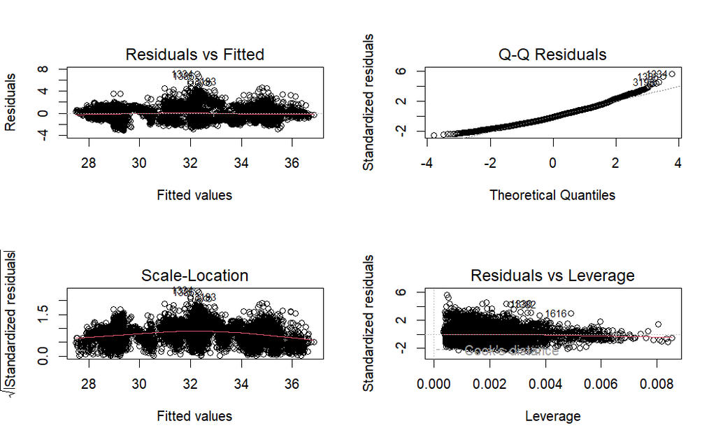

```r
par(mfrow=c(2,2))
plot(bcmodel02)
```

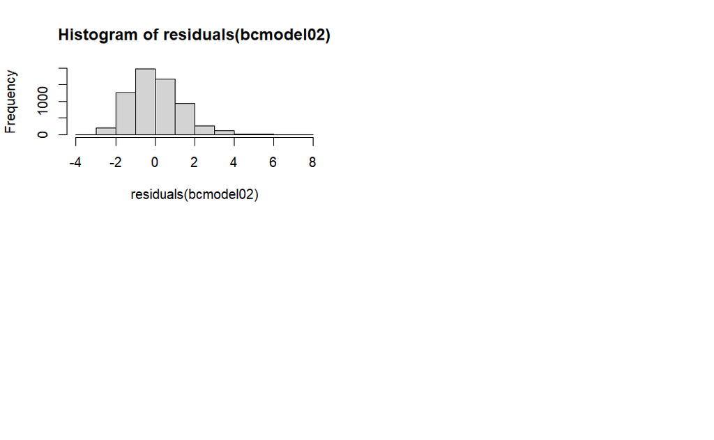

```r
hist(residuals(bcmodel02))
```

**Equal Variances**

- **The Breusch-Pagan Test** The hypothesis: $H_{0}:\text{common variance}; H_{\alpha}:\text{non-common variance}$

```r
bptest(bcmodel02)
```

```
    studentized Breusch-Pagan test

data:  bcmodel02
BP = 620.04, df = 11, p-value < 2.2e-16
```

- p value <0.05, reject Null, we do have heteroscedasticity

**Normality Assumption**

**Anderson-Darling test**

- Since Shapiro-Wilk Test couldnt perform on large sample size over 5000 rows. We use Anderson-Darling test instead.
- The Hypothesis : $H_{0}: \text{we have normality}; \; H_{\alpha}: \text{we do not have normality}$

```r
library(nortest)
bcmodel02_results <- ad.test(residuals(bcmodel02))
print(bcmodel02_results)
```

```
    Anderson-Darling normality test

data:  residuals(bcmodel02)
A = 23.284, p-value < 2.2e-16
```

- pvalue <0.05, reject Null, we don’t have normality.

**Conclusion on box cox transformed model**

Normality : There is still a concern on normality in this model

Linearity: The residuals are scattered around the horizontal line without a clear pattern, which is a good indication of linearity.

Equal Variance:From The Breusch-Pagan Test result with extremely low p value, we we do have heteroscedasticity

#### 2.4 Check for outliers

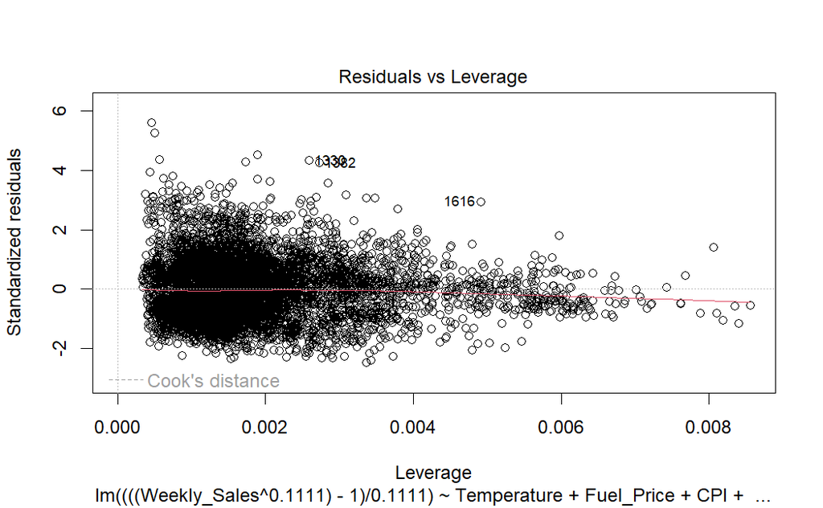

```r
plot(bcmodel02,which=5)
```

- **Cooks Distance**

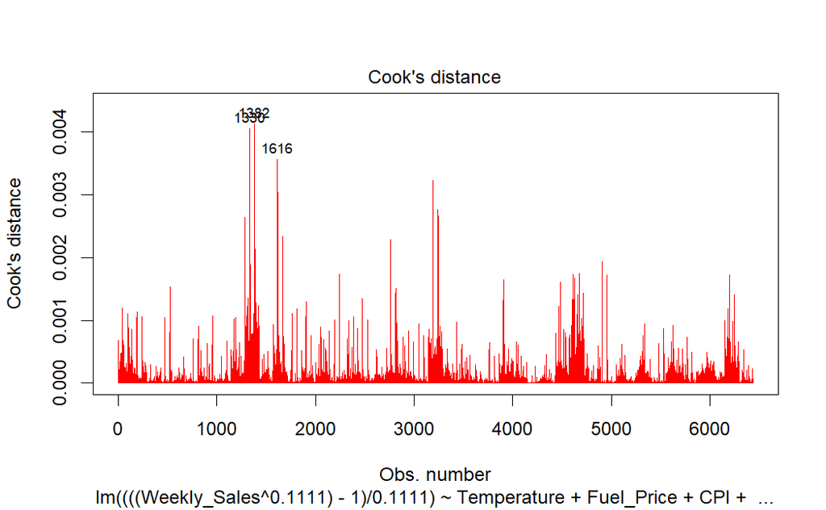

```r
plot(bcmodel02,pch=18,col="red",which=c(4)) #which =4 only prints the cook distance plot
```

**Leverage Points**

```r
lev=hatvalues(bcmodel02)
p = length(coef(bcmodel02))
n = nrow(walmartNEW)
outlier2p = lev[lev>(2*p/n)]
outlier3p = lev[lev>(3*p/n)]
print("h_I>3p/n, outliers are")
```

```
[1] "h_I>3p/n, outliers are"
```

```r
print(outlier3p)
```

```
        565         708        3862        3863        3864        3865        3866        3867        3870        3871
0.007062426 0.005899419 0.005738211 0.007683228 0.005679741 0.005914245 0.005595875 0.005757812 0.005598890 0.005599977
       3873        3874        3875        3877        3878        3879        3880        3881        3882        3883
0.005638677 0.005600367 0.005617340 0.005770047 0.005674490 0.006257248 0.006781412 0.006061177 0.006304833 0.006681410
       3884        3885        3886        3887        3888        3889        3890        3891        3892        3893
0.006583345 0.007079708 0.007217110 0.007160213 0.006723722 0.006307672 0.006854883 0.006730687 0.006208576 0.008555368
       3894        3895        3896        3897        3898        3899        3900        3901        3902        3903
0.006267529 0.006396152 0.006646874 0.006130711 0.006266601 0.006070157 0.006025287 0.005896398 0.005931964 0.005900145
       3904        3905        3906        3907        3908        3909        3910        3911        3914        3915
0.008060857 0.006421723 0.006060253 0.005959554 0.005974333 0.008097406 0.006129579 0.005818451 0.005703773 0.007423092
       3917        3918        3919        3921        3925        3926        3927        3928        3929        3945
0.005631554 0.005643686 0.005651751 0.005903895 0.005631811 0.005684644 0.005788213 0.005793469 0.005742117 0.007611877
       3956        3961        5292        5293        5294        5295        5296        5297        5300        5301
0.005873805 0.005913015 0.006026067 0.007880909 0.005863602 0.006158556 0.005810737 0.006022462 0.005743184 0.005755319
       5302        5303        5304        5305        5306        5307        5308        5309        5310        5311
0.005630742 0.005697888 0.005624340 0.005600175 0.005599599 0.005648947 0.005686534 0.006009983 0.006371834 0.005841220
       5312        5313        5314        5315        5316        5317        5318        5319        5320        5321
0.005985016 0.006292437 0.006221165 0.006597447 0.006703424 0.006677622 0.006322659 0.006018470 0.006439078 0.006326627
       5322        5323        5324        5325        5326        5327        5328        5329        5330        5331
0.005971282 0.008184853 0.006028485 0.006149164 0.006366945 0.006086662 0.006157537 0.006075462 0.006164991 0.005982337
       5332        5333        5334        5335        5336        5337        5338        5339        5340        5341
0.006150700 0.006116900 0.008342890 0.006866392 0.006421965 0.006277624 0.006301840 0.008396730 0.006665938 0.006262303
       5342        5343        5344        5345        5346        5347        5348        5349        5351        5355
0.005680476 0.005803877 0.006106936 0.007611730 0.005682012 0.006001219 0.005982475 0.005913809 0.006232448 0.005662124
       5356        5357        5358        5359        5375        5386        5391        6090        6106        6142
0.005779534 0.005887293 0.005851846 0.005865514 0.007206544 0.005920779 0.006061898 0.007014463 0.005663089 0.005621946
```

```r
plot(rownames(walmartNEW),lev, main = "Leverage in Walmart Sales Dataset", xlab="observation",
ylab = "Leverage Value")
abline(h = 2 *p/n, lty = 1)
```

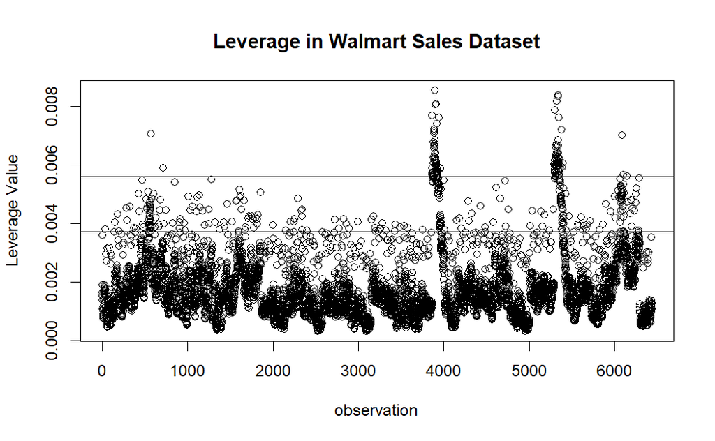

```r
abline(h = 3 *p/n, lty = 1)
```

##### 2.7 Remove outliers

```r
outlier_indices <- as.numeric(names(outlier3p))
walmart02 <- walmartNEW[-outlier_indices, ]
nrow(walmart02)
```

```
[1] 6305
```

```r
nrow(walmartNEW)
```

```
[1] 6435
```

**Model after remove outliers**

**Full Additive Model**

```r
full02 = lm(Weekly_Sales~Temperature+Fuel_Price+CPI+Unemployment+Size+Holiday_Flag,data=walmart02)
summary(full02)
```

```
Call:
lm(formula = Weekly_Sales ~ Temperature + Fuel_Price + CPI +
    Unemployment + Size + Holiday_Flag, data = walmart02)

Residuals:
    Min      1Q  Median      3Q     Max
-632388 -250669  -20925  160508 2690602

Coefficients:
                  Estimate Std. Error t value Pr(>|t|)
(Intercept)      4.752e+05  4.890e+04   9.717  < 2e-16 ***
Temperature      1.453e+03  2.387e+02   6.086 1.22e-09 ***
Fuel_Price      -2.649e+04  9.339e+03  -2.837  0.00457 **
CPI             -1.410e+03  1.150e+02 -12.261  < 2e-16 ***
Unemployment    -1.718e+04  2.587e+03  -6.641 3.38e-11 ***
Size             7.270e+00  6.644e-02 109.435  < 2e-16 ***
Holiday_FlagYes  9.609e+04  1.663e+04   5.778 7.94e-09 ***
---
Signif. codes:  0 ‘***’ 0.001 ‘**’ 0.01 ‘*’ 0.05 ‘.’ 0.1 ‘ ’ 1

Residual standard error: 327600 on 6298 degrees of freedom
Multiple R-squared:  0.6632,    Adjusted R-squared:  0.6629
F-statistic:  2067 on 6 and 6298 DF,  p-value: < 2.2e-16
```

**Interaction Model**

```r
interact01_walmart02 = lm(Weekly_Sales~(Temperature+Fuel_Price+CPI+Unemployment+Size+Holiday_Flag)^2,data=walmart02)
summary(interact01_walmart02)
```

```
Call:
lm(formula = Weekly_Sales ~ (Temperature + Fuel_Price + CPI +
    Unemployment + Size + Holiday_Flag)^2, data = walmart02)

Residuals:
    Min      1Q  Median      3Q     Max
-739914 -231254  -17800  145585 2723674

Coefficients:
                               Estimate Std. Error t value Pr(>|t|)
(Intercept)                   1.462e+06  3.270e+05   4.470 7.96e-06 ***
Temperature                   3.084e+03  2.789e+03   1.106  0.26878
Fuel_Price                   -2.129e+05  8.137e+04  -2.617  0.00890 **
CPI                          -1.176e+04  1.220e+03  -9.638  < 2e-16 ***
Unemployment                 -1.084e+05  2.776e+04  -3.905 9.50e-05 ***
Size                          1.235e+01  7.599e-01  16.250  < 2e-16 ***
Holiday_FlagYes               3.062e+04  2.068e+05   0.148  0.88226
Temperature:Fuel_Price        1.550e+03  5.642e+02   2.747  0.00603 **
Temperature:CPI              -3.551e+01  6.356e+00  -5.586 2.42e-08 ***
Temperature:Unemployment      9.916e+00  1.385e+02   0.072  0.94293
Temperature:Size             -3.873e-03  3.776e-03  -1.026  0.30509
Temperature:Holiday_FlagYes   8.919e+02  8.768e+02   1.017  0.30911
Fuel_Price:CPI                1.300e+03  2.584e+02   5.033 4.95e-07 ***
Fuel_Price:Unemployment      -1.259e+04  6.255e+03  -2.012  0.04424 *
Fuel_Price:Size              -8.211e-02  1.471e-01  -0.558  0.57671
Fuel_Price:Holiday_FlagYes    7.131e+03  4.219e+04   0.169  0.86578
CPI:Unemployment              1.245e+03  8.118e+01  15.334  < 2e-16 ***
CPI:Size                     -8.147e-03  1.770e-03  -4.602 4.26e-06 ***
CPI:Holiday_FlagYes          -6.658e+02  4.556e+02  -1.461  0.14397
Unemployment:Size            -3.938e-01  4.422e-02  -8.906  < 2e-16 ***
Unemployment:Holiday_FlagYes  4.215e+03  1.098e+04   0.384  0.70104
Size:Holiday_FlagYes          6.052e-01  2.617e-01   2.312  0.02078 *
---
Signif. codes:  0 ‘***’ 0.001 ‘**’ 0.01 ‘*’ 0.05 ‘.’ 0.1 ‘ ’ 1

Residual standard error: 316200 on 6283 degrees of freedom
Multiple R-squared:  0.6871,    Adjusted R-squared:  0.6861
F-statistic:   657 on 21 and 6283 DF,  p-value: < 2.2e-16
```

**Reduced Interaction Model**

```r
interact02_walmart02 = lm(Weekly_Sales~Temperature+Fuel_Price+CPI+Unemployment+Size+Holiday_Flag+
                          Temperature*Fuel_Price+ Temperature*CPI +
                          Fuel_Price*CPI+
                          CPI*Unemployment+CPI*Size+
                          Unemployment*Size + Size*Holiday_Flag,data=walmart02)
summary(interact02_walmart02)
```

```
Call:
lm(formula = Weekly_Sales ~ Temperature + Fuel_Price + CPI +
    Unemployment + Size + Holiday_Flag + Temperature * Fuel_Price +
    Temperature * CPI + Fuel_Price * CPI + CPI * Unemployment +
    CPI * Size + Unemployment * Size + Size * Holiday_Flag, data = walmart02)

Residuals:
    Min      1Q  Median      3Q     Max
-742955 -228662  -19942  145609 2722569

Coefficients:
                         Estimate Std. Error t value Pr(>|t|)
(Intercept)             1.980e+06  2.218e+05   8.924  < 2e-16 ***
Temperature             3.399e+03  2.276e+03   1.494   0.1353
Fuel_Price             -3.416e+05  5.024e+04  -6.799 1.15e-11 ***
CPI                    -1.271e+04  1.147e+03 -11.087  < 2e-16 ***
Unemployment           -1.560e+05  1.380e+04 -11.302  < 2e-16 ***
Size                    1.183e+01  5.161e-01  22.926  < 2e-16 ***
Holiday_FlagYes         1.533e+04  3.718e+04   0.412   0.6802
Temperature:Fuel_Price  1.337e+03  5.498e+02   2.431   0.0151 *
Temperature:CPI        -3.512e+01  6.137e+00  -5.722 1.10e-08 ***
Fuel_Price:CPI          1.481e+03  2.453e+02   6.038 1.65e-09 ***
CPI:Unemployment        1.278e+03  7.943e+01  16.087  < 2e-16 ***
CPI:Size               -8.055e-03  1.686e-03  -4.779 1.81e-06 ***
Unemployment:Size      -3.974e-01  4.393e-02  -9.046  < 2e-16 ***
Size:Holiday_FlagYes    6.253e-01  2.555e-01   2.448   0.0144 *
---
Signif. codes:  0 ‘***’ 0.001 ‘**’ 0.01 ‘*’ 0.05 ‘.’ 0.1 ‘ ’ 1

Residual standard error: 316200 on 6291 degrees of freedom
Multiple R-squared:  0.6866,    Adjusted R-squared:  0.6859
F-statistic:  1060 on 13 and 6291 DF,  p-value: < 2.2e-16
```

**Box Cox Transformed Model**

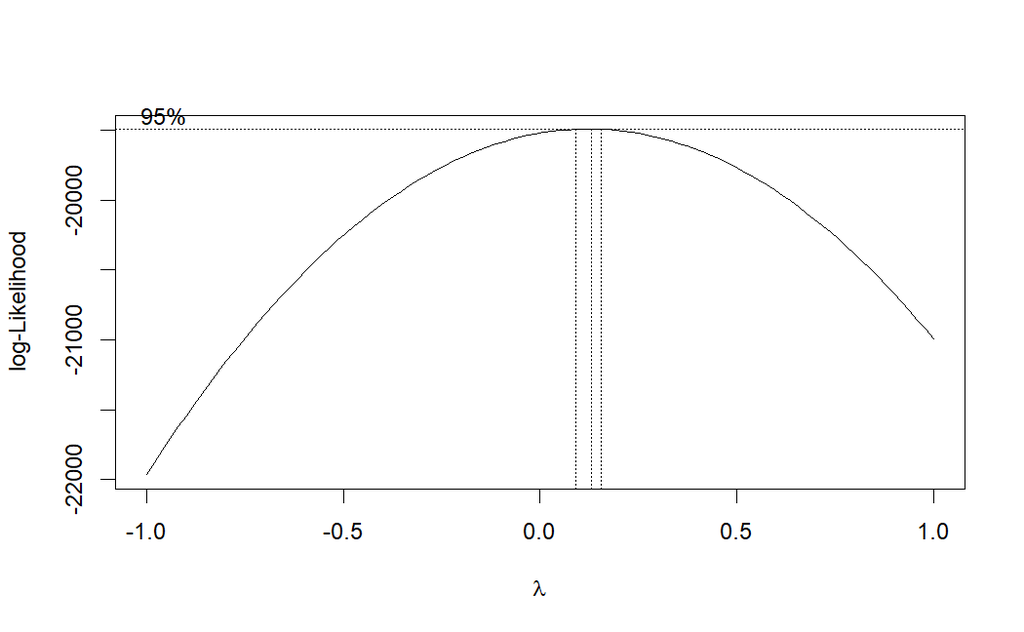

```r
library(MASS)
bc03=boxcox(interact02_walmart02,lambda=seq(-1,1))
```

```r
bestlambda02=bc03$x[which(bc03$y==max(bc03$y))]
bestlambda02
```

```
[1] 0.1313131
```

**Fit model with this lambda**

```r
bcmodel03=lm((((Weekly_Sales^0.1313)-1)/0.1313) ~ Temperature+Fuel_Price+CPI+Unemployment+Size+Holiday_Flag+
                          Temperature*Fuel_Price+ Temperature*CPI +
                          Fuel_Price*CPI+
                          CPI*Unemployment+CPI*Size+
                          Unemployment*Size + Size*Holiday_Flag,data=walmart02)
summary(bcmodel03)
```

```
Call:
lm(formula = (((Weekly_Sales^0.1313) - 1)/0.1313) ~ Temperature +
    Fuel_Price + CPI + Unemployment + Size + Holiday_Flag + Temperature *
    Fuel_Price + Temperature * CPI + Fuel_Price * CPI + CPI *
    Unemployment + CPI * Size + Unemployment * Size + Size *
    Holiday_Flag, data = walmart02)

Residuals:
   Min     1Q Median     3Q    Max
-3.999 -1.238 -0.149  1.056  9.461

Coefficients:
                         Estimate Std. Error t value Pr(>|t|)
(Intercept)             4.262e+01  1.181e+00  36.100  < 2e-16 ***
Temperature             1.809e-02  1.211e-02   1.494 0.135282
Fuel_Price             -1.347e+00  2.674e-01  -5.038 4.83e-07 ***
CPI                    -8.205e-02  6.102e-03 -13.445  < 2e-16 ***
Unemployment           -9.295e-01  7.343e-02 -12.659  < 2e-16 ***
Size                    7.213e-05  2.746e-06  26.263  < 2e-16 ***
Holiday_FlagYes         2.853e-01  1.978e-01   1.442 0.149328
Temperature:Fuel_Price  2.009e-03  2.926e-03   0.687 0.492350
Temperature:CPI        -1.114e-04  3.266e-05  -3.412 0.000648 ***
Fuel_Price:CPI          7.652e-03  1.305e-03   5.862 4.82e-09 ***
CPI:Unemployment        8.083e-03  4.227e-04  19.122  < 2e-16 ***
CPI:Size               -3.762e-08  8.970e-09  -4.194 2.78e-05 ***
Unemployment:Size      -2.170e-06  2.338e-07  -9.285  < 2e-16 ***
Size:Holiday_FlagYes    1.328e-06  1.360e-06   0.977 0.328573
---
Signif. codes:  0 ‘***’ 0.001 ‘**’ 0.01 ‘*’ 0.05 ‘.’ 0.1 ‘ ’ 1

Residual standard error: 1.683 on 6291 degrees of freedom
Multiple R-squared:  0.7701,    Adjusted R-squared:  0.7697
F-statistic:  1621 on 13 and 6291 DF,  p-value: < 2.2e-16
```

**Reduced box cox model**

- Removed insignificance

```r
bcmodel04=lm((((Weekly_Sales^0.1313)-1)/0.1313) ~ Temperature+Fuel_Price+CPI+Unemployment+Size+Holiday_Flag+
                          Temperature*CPI +
                          Fuel_Price*CPI+
                          CPI*Unemployment+CPI*Size+
                          Unemployment*Size,data=walmart02)
summary(bcmodel04)
```

```
Call:
lm(formula = (((Weekly_Sales^0.1313) - 1)/0.1313) ~ Temperature +
    Fuel_Price + CPI + Unemployment + Size + Holiday_Flag + Temperature *
    CPI + Fuel_Price * CPI + CPI * Unemployment + CPI * Size +
    Unemployment * Size, data = walmart02)

Residuals:
    Min      1Q  Median      3Q     Max
-4.1204 -1.2404 -0.1505  1.0535  9.4587

Coefficients:
                    Estimate Std. Error t value Pr(>|t|)
(Intercept)        4.224e+01  1.053e+00  40.106  < 2e-16 ***
Temperature        2.543e-02  5.572e-03   4.564 5.12e-06 ***
Fuel_Price        -1.245e+00  2.229e-01  -5.589 2.38e-08 ***
CPI               -8.232e-02  6.091e-03 -13.514  < 2e-16 ***
Unemployment      -9.295e-01  7.342e-02 -12.660  < 2e-16 ***
Size               7.211e-05  2.738e-06  26.340  < 2e-16 ***
Holiday_FlagYes    4.643e-01  8.546e-02   5.432 5.77e-08 ***
Temperature:CPI   -1.158e-04  3.198e-05  -3.621 0.000296 ***
Fuel_Price:CPI     7.802e-03  1.287e-03   6.062 1.43e-09 ***
CPI:Unemployment   8.082e-03  4.227e-04  19.123  < 2e-16 ***
CPI:Size          -3.728e-08  8.958e-09  -4.162 3.20e-05 ***
Unemployment:Size -2.166e-06  2.335e-07  -9.278  < 2e-16 ***
---
Signif. codes:  0 ‘***’ 0.001 ‘**’ 0.01 ‘*’ 0.05 ‘.’ 0.1 ‘ ’ 1

Residual standard error: 1.683 on 6293 degrees of freedom
Multiple R-squared:  0.7701,    Adjusted R-squared:  0.7697
F-statistic:  1916 on 11 and 6293 DF,  p-value: < 2.2e-16
```

**Assumptions Check**

**Plots**

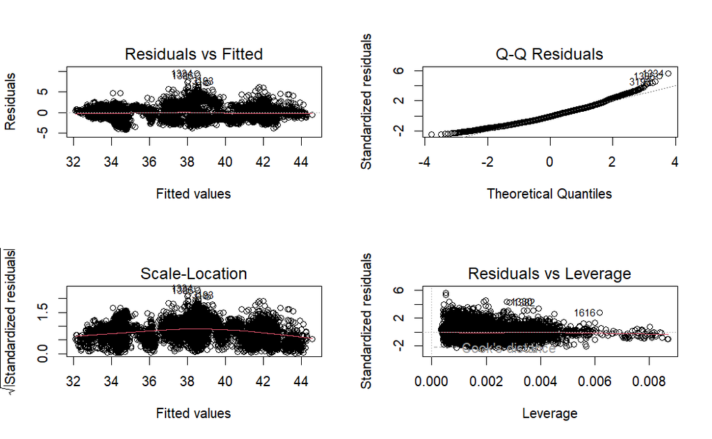

```r
par(mfrow=c(2,2))
plot(bcmodel04)
```

**Equal Variances**

**The Breusch-Pagan Test**

```r
library(lmtest)
bptest(bcmodel04)
```

```
    studentized Breusch-Pagan test

data:  bcmodel04
BP = 593.7, df = 11, p-value < 2.2e-16
```

- p value <0.05, reject Null, we do have heteroscedasticity

**Normality Assumption**

**Anderson-Darling test**

- Since Shapiro-Wilk Test couldnt perform on large sample size over 5000 rows. We use Anderson-Darling test instead.
- The Hypothesis : $H_{0}: \text{we have normality}; \; H_{\alpha}: \text{we do not have normality}$

```r
library(nortest)
bcmodel04_results <- ad.test(residuals(bcmodel04))
print(bcmodel04_results)
```

```
    Anderson-Darling normality test

data:  residuals(bcmodel04)
A = 23.079, p-value < 2.2e-16
```

- pvalue <0.05, reject Null, we don’t have normality.

**Conclusion**

- With transformed models on refinded dataset walmart02, we couldn’t get rid of heteroscedasticity in a regression model.
- Next step, perform Weighted Least Squares to improve our model. This is not cover in class for DATA603, we did research by ourselves so there might be a knowledge gap in applying it properly. But we did give it a try.

#### 2.8 Weight Least Square method

#### 2.8.1 WLS on full dataset without removing outliers

```r
fitted_values01 <- fitted(bcmodel02)
weights01 <- 1 / (fitted_values01^2)
wls01 <- lm((((Weekly_Sales^0.1111)-1)/0.1111) ~
              Temperature+Fuel_Price+CPI+Unemployment+Size+Holiday_Flag+
                          Temperature*CPI +
                          Fuel_Price*CPI+
                          CPI*Unemployment+CPI*Size+
                          Unemployment*Size,data=walmartNEW,weight = weights01)
summary(wls01)
```

```
Call:
lm(formula = (((Weekly_Sales^0.1111) - 1)/0.1111) ~ Temperature +
    Fuel_Price + CPI + Unemployment + Size + Holiday_Flag + Temperature *
    CPI + Fuel_Price * CPI + CPI * Unemployment + CPI * Size +
    Unemployment * Size, data = walmartNEW, weights = weights01)

Weighted Residuals:
      Min        1Q    Median        3Q       Max
-0.103267 -0.028749 -0.003977  0.025613  0.220452

Coefficients:
                    Estimate Std. Error t value Pr(>|t|)
(Intercept)        3.522e+01  7.640e-01  46.102  < 2e-16 ***
Temperature        1.623e-02  4.118e-03   3.942 8.16e-05 ***
Fuel_Price        -7.781e-01  1.657e-01  -4.696 2.70e-06 ***
CPI               -6.145e-02  4.471e-03 -13.743  < 2e-16 ***
Unemployment      -8.315e-01  4.839e-02 -17.184  < 2e-16 ***
Size               5.478e-05  1.949e-06  28.102  < 2e-16 ***
Holiday_FlagYes    3.219e-01  6.328e-02   5.088 3.73e-07 ***
Temperature:CPI   -7.400e-05  2.369e-05  -3.124  0.00179 **
Fuel_Price:CPI     5.117e-03  9.572e-04   5.345 9.33e-08 ***
CPI:Unemployment   6.571e-03  2.966e-04  22.158  < 2e-16 ***
CPI:Size          -4.604e-08  6.737e-09  -6.834 9.03e-12 ***
Unemployment:Size -1.183e-06  1.428e-07  -8.286  < 2e-16 ***
---
Signif. codes:  0 ‘***’ 0.001 ‘**’ 0.01 ‘*’ 0.05 ‘.’ 0.1 ‘ ’ 1

Residual standard error: 0.03947 on 6423 degrees of freedom
Multiple R-squared:  0.7824,    Adjusted R-squared:  0.782
F-statistic:  2099 on 11 and 6423 DF,  p-value: < 2.2e-16
```

- Everything looks significant in this model

$$\begin{align*}
\left( \left( \text{Weekly_Sales}^{0.1111} \right) - 1 \right) / 0.1111
= & \ 35.220 + 0.016\text{Temperature}_i - 0.778\text{Fuel_price}_i
\\
& \ - 0.061\text{CPI}_i - 0.831\text{Unemployment}_i + 5.478 \times
10^{-5}\text{Size}_i + 0.3219\text{HolidayFlag}_i \\
& \ -7.400 \times 10^{-5}\text{Temperature}_i \times \text{CPI}_i +
0.005\text{Fuel_price}_i \times \text{CPI}_i + \\
& \ +0.006 \text{CPI}_i \times \text{Unemployment}_i - 4.604 \times
10^{-8} \text{CPI}_i \times \text{Size}_i \\
& \ -1.183 \times 10^{-6} \text{Unemployment}_i \times \text{Size}_i
\end{align*}$$

**Assumptions Check**

**Plots**

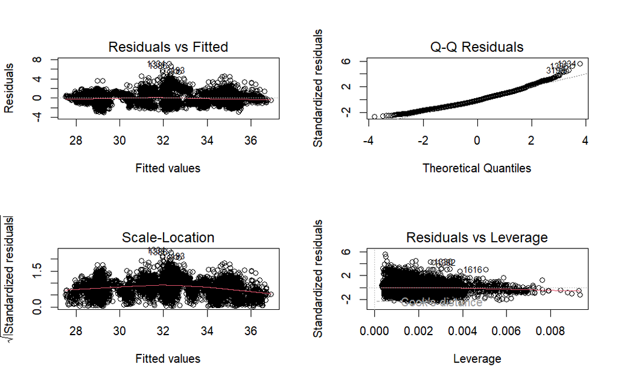

```r
par(mfrow=c(2,2))
plot(wls01)
```

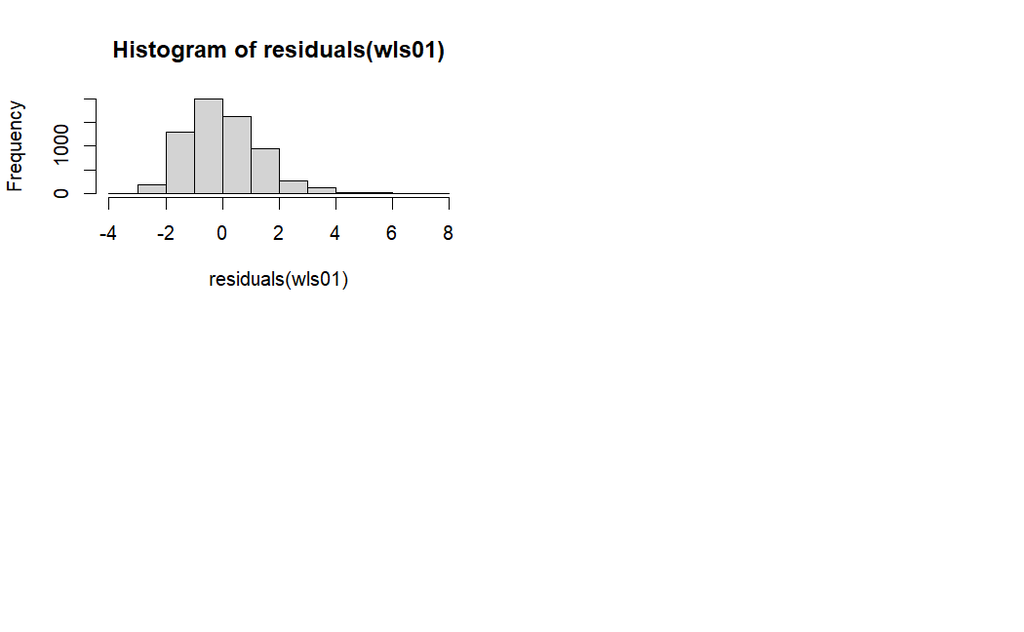

```r
hist(residuals(wls01))
```

**Equal Variances**

**The Breusch-Pagan Test**

```r
library(lmtest)
bptest(wls01)
```

```
    studentized Breusch-Pagan test

data:  wls01
BP = 2.1335, df = 11, p-value = 0.998
```

pvalue >0.05, fail to reject Null, we do have homoscedasticity

**Normality Assumption**

**Anderson-Darling test**

- Since Shapiro-Wilk Test couldnt perform on large sample size over 5000 rows. We use Anderson-Darling test instead
- The Hypothesis : $H_{0}: \text{we have normality}; \; H_{\alpha}: \text{we do not have normality}$

```r
library(nortest)
wls01_results <- ad.test(residuals(wls01))
print(wls01_results)
```

```
    Anderson-Darling normality test

data:  residuals(wls01)
A = 28.214, p-value < 2.2e-16
```

- pvalue <0.05, reject Null, we don’t have normality.

**Conclusion from this model**

- By applying WLS, we not only got significance in our model with higher AdjRsq and lower RSE, but we also met our equal variances assumption which we were struggling to solve it with OLS method. The spread of residuals across the range of fitted values does not show the same pattern of increasing spread with the increase in fitted values as before. This suggests that the heteroscedasticity may have been mitigated.
- However, there is still a concern about normality assumption based on its QQ plot. The Q-Q plot of the WLS model seems to have a slightly better alignment in the middle quantiles but still shows heavy tails.
- Next step, we test on model with removed outliers since the outliers are the heavy influencers on our normality.

#### 2.8.2 WLS on refined dataset with outliers removed

```r
fitted_values02 <- fitted(bcmodel04)
weights02 <- 1 / (fitted_values02^2)
wls02 <- lm((((Weekly_Sales^0.1313)-1)/0.1313) ~ Temperature+Fuel_Price+CPI+Unemployment+Size+Holiday_Flag+
                          Temperature*CPI +
                          Fuel_Price*CPI+
                          CPI*Unemployment+CPI*Size+
                          Unemployment*Size,data=walmart02,weights = weights02)
summary(wls02)
```

```
Call:
lm(formula = (((Weekly_Sales^0.1313) - 1)/0.1313) ~ Temperature +
    Fuel_Price + CPI + Unemployment + Size + Holiday_Flag + Temperature *
    CPI + Fuel_Price * CPI + CPI * Unemployment + CPI * Size +
    Unemployment * Size, data = walmart02, weights = weights02)

Weighted Residuals:
      Min        1Q    Median        3Q       Max
-0.113967 -0.032362 -0.004463  0.028203  0.245755

Coefficients:
                    Estimate Std. Error t value Pr(>|t|)
(Intercept)        4.120e+01  1.038e+00  39.714  < 2e-16 ***
Temperature        2.287e-02  5.572e-03   4.105 4.10e-05 ***
Fuel_Price        -1.102e+00  2.230e-01  -4.942 7.94e-07 ***
CPI               -7.696e-02  5.986e-03 -12.857  < 2e-16 ***
Unemployment      -9.250e-01  7.171e-02 -12.898  < 2e-16 ***
Size               7.691e-05  2.768e-06  27.786  < 2e-16 ***
Holiday_FlagYes    4.435e-01  8.611e-02   5.150 2.68e-07 ***
Temperature:CPI   -1.053e-04  3.187e-05  -3.306 0.000952 ***
Fuel_Price:CPI     7.069e-03  1.282e-03   5.513 3.67e-08 ***
CPI:Unemployment   8.068e-03  4.112e-04  19.618  < 2e-16 ***
CPI:Size          -6.329e-08  8.954e-09  -7.068 1.74e-12 ***
Unemployment:Size -2.127e-06  2.338e-07  -9.096  < 2e-16 ***
---
Signif. codes:  0 ‘***’ 0.001 ‘**’ 0.01 ‘*’ 0.05 ‘.’ 0.1 ‘ ’ 1

Residual standard error: 0.04394 on 6293 degrees of freedom
Multiple R-squared:  0.7774,    Adjusted R-squared:  0.777
F-statistic:  1998 on 11 and 6293 DF,  p-value: < 2.2e-16
```

**Assumptions Check**

**Plots**

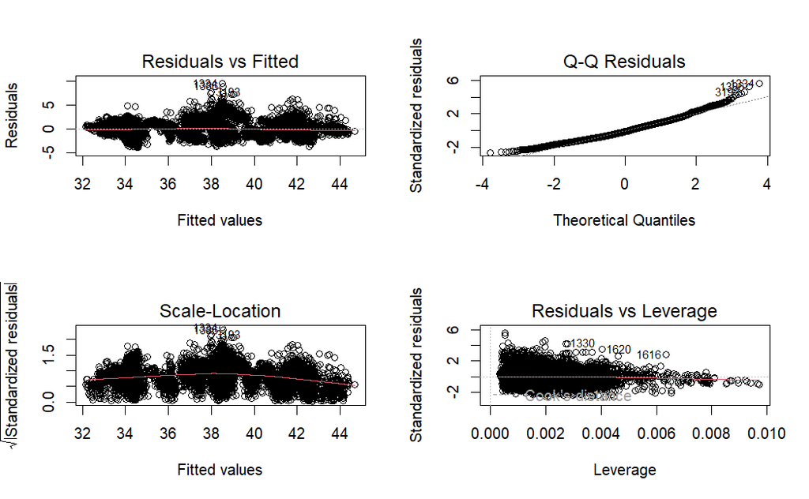

```r
par(mfrow=c(2,2))
plot(wls02)
```

**Normality Assumption**

**Anderson-Darling test**

- Since Shapiro-Wilk Test couldnt perform on large sample size over 5000 rows. We use Anderson-Darling test instead.
- The Hypothesis : $H_{0}: \text{we have normality}; \; H_{\alpha}: \text{we do not have normality}$

```r
library(nortest)
wls02_results <- ad.test(residuals(wls02))
print(wls02_results)
```

```
    Anderson-Darling normality test

data:  residuals(wls02)
A = 28.479, p-value < 2.2e-16
```

- pvalue <0.05, reject Null, we don’t have normality.

**Equal Variances**

**The Breusch-Pagan Test**

```r
library(lmtest)
bptest(wls02)
```

```
    studentized Breusch-Pagan test

data:  wls02
BP = 1.4568, df = 11, p-value = 0.9997
```

- pvalue >0.05, fail to reject Null, we do have homoscedasticity

**Conclusion**

Linearity:

- The removal of outliers seems to have resulted in a more uniform spread of residuals across the range of fitted values.
- The residuals are scattered around the horizontal line without a clear pattern, which is a good indication of linearity.

  Equal Variance: Based on The Breusch-Pagan Test, we do have homoscedasticity. Normality:
- There is still a concern on normality in this model.
- However, we expect this result as normality tests are known to be sensitive to large samples.Additionally, we’re looking for predictive accuracy, and with limited knowledge at this stage, we accept the violation of the normality which means normality assumption might not be a significant issue.

#### 2.9 Experimental Design

#### 2.9.1 Are sales relatively higher during holiday seasons?**

- We use Kruskal Test as this is a non parametric approach
- The Hypothesis : $H_{0}:\mu_{Holiday}=\mu_{Non Holiday}= 0; H_{\alpha}: \mu_{Holiday}\neq\mu_{Non Holiday}$

```r
kruskal.test(Weekly_Sales~Holiday_Flag, data = walmartNEW)
```

```
    Kruskal-Wallis rank sum test

data:  Weekly_Sales by Holiday_Flag
Kruskal-Wallis chi-squared = 4.9633, df = 1, p-value = 0.02589
```

- p value <0.05. We can conclude that average sales are different on weeks with a holiday compared to weeks without

```r
library(FSA)
DT = dunnTest(Weekly_Sales~Holiday_Flag, data = walmartNEW,method="none")
DT
```

```
Dunn (1964) Kruskal-Wallis multiple comparison
  with no adjustment for p-values.
```

| Comparison | Z | P.unadj | P.adj |
| --- | --- | --- | --- |
| No - Yes | -2.22784 | 0.02589115 | 0.02589115 |

- Since the p-value is less than 0.05, it suggests that there is a statistically significant difference between the two groups at the 5% significance level. The test suggests that there is a statistically significant difference in weekly sales between the weeks with a holiday and those without.
- Since the z-value is negative, this suggest that sales are higher on weeks with a holiday compared to weeks without.

#### 2.9.2 Are sales relatively higher if the store is larger according to Store Type?**

- We use Kruskal Test as this is a non parametric approach
- The Hypothesis : $H_{0}:\mu_{Type A Store}=\mu_{Type B Store}= \mu_{Type C Store}= 0; H_{\alpha}: \text{at least one }\mu_{i} \text{ is different i = 1,2,3...,c}$

```r
kruskal.test(Weekly_Sales~Type, data = walmartNEW)
```

```
    Kruskal-Wallis rank sum test

data:  Weekly_Sales by Type
Kruskal-Wallis chi-squared = 2541.6, df = 2, p-value < 2.2e-16
```

```r
library(FSA)
DT01 = dunnTest(Weekly_Sales~factor(Type), data = walmartNEW,method="none")
DT01
```

```
Dunn (1964) Kruskal-Wallis multiple comparison
  with no adjustment for p-values.
```

| Comparison | Z | P.unadj | P.adj |
| --- | --- | --- | --- |
| A - B | 35.91247 | 1.951701e-282 | 1.951701e-282 |
| A - C | 44.66469 | 0.000000e+00 | 0.000000e+00 |
| B - C | 18.89859 | 1.171385e-79 | 1.171385e-79 |

- Since the p-values are less than 0.05, it suggests that there are a statistically significant difference between the 3 groups. The test suggests that there is a statistically significant difference in weekly sales between Type of Store.
- Since the z-values is positive, this suggest that Type A Stores’ sales are higher than Type B & Type C. Sales of Store Type B is higher than Type C .